# U.S 2020 Election spread analysis

Pratyush Singh

27/07/2020

## INTRODUCTION

This is a report on 2020 U.S election votes spread from summarising data of various pollster’s reports as of July2020 . The original data was obtained from [this page](https://projects.fivethirtyeight.com/polls-page/president_polls.csv).

We are going to use the following library:

```r
library(tidyverse)
library(dslabs)
library(ggplot2)
library(prettydoc)
```

# DATA PREPARATION

Initial Table of Data .

```r
Polls_init <- read.csv("data/president_polls.csv")
```

```
##   question_id poll_id cycle    state pollster_id              pollster
## 1      125127   66992  2020  Florida        1250       Trafalgar Group
## 2      125127   66992  2020  Florida        1250       Trafalgar Group
## 3      125124   66988  2020                  568                YouGov
## 4      125124   66988  2020                  568                YouGov
## 5      125078   66973  2020 Colorado         383 Public Policy Polling
## 6      125078   66973  2020 Colorado         383 Public Policy Polling
##   sponsor_ids            sponsors          display_name pollster_rating_id
## 1                                       Trafalgar Group                338
## 2                                       Trafalgar Group                338
## 3        1213          Yahoo News                YouGov                391
## 4        1213          Yahoo News                YouGov                391
## 5         681 End Citizens United Public Policy Polling                263
## 6         681 End Citizens United Public Policy Polling                263
##    pollster_rating_name fte_grade sample_size population population_full
```

[output cut: 41 more lines]

Filter for two major candidate (Donald j. Trump & Joesph Biden), High graded Pollsters & Selected relevant variables . Grouped by Unique Question_id for each poll.

```r
poll_filter <- Polls_init %>% filter(candidate_name %in% c("Donald Trump","Joseph R. Biden Jr.") & (fte_grade %in% c("A+", "A", "A-", "B+") | is.na(fte_grade))) %>%
  select("question_id","state","pollster","fte_grade","sample_size","population","start_date","end_date","candidate_name","pct") %>%
  group_by(question_id)
```

```
## # A tibble: 6 x 10
## # Groups:   question_id [3]
##   question_id state pollster fte_grade sample_size population start_date
##         <int> <fct> <fct>    <fct>           <int> <fct>      <fct>
## 1      125108 ""    Monmout… A+                733 rv         6/26/20
## 2      125108 ""    Monmout… A+                733 rv         6/26/20
## 3      125017 ""    Suffolk… A                1000 rv         6/25/20
## 4      125017 ""    Suffolk… A                1000 rv         6/25/20
## 5      125018 ""    Suffolk… A                1000 rv         6/25/20
## 6      125018 ""    Suffolk… A                1000 rv         6/25/20
## # … with 3 more variables: end_date <fct>, candidate_name <fct>, pct <dbl>
```

Converted Two candidates as variables for comparision in following steps

-Seperated both variables into two different dataframes - Merged both variable by unique question_id

```r
trump2020 <- poll_filter %>% rowid_to_column() %>%spread(candidate_name , pct) %>% select( -rowid , -`Joseph R. Biden Jr.`) %>% filter(!is.na(`Donald Trump`))
joe_biden2020  <- poll_filter %>% rowid_to_column()%>%spread(candidate_name , pct) %>% filter(!is.na(`Joseph R. Biden Jr.`))%>% select( question_id , `Joseph R. Biden Jr.`)

poll_2020 <- merge(trump2020 , joe_biden2020 , by = "question_id")
```

```
##   question_id          state              pollster fte_grade sample_size
## 1       92974           Iowa       Emerson College        A-         831
## 2       93173                      Emerson College        A-        1000
## 3       93181                      Emerson College        A-        1000
## 4       93281  New Hampshire       Emerson College        A-         910
## 5       93369          Texas Quinnipiac University        B+        1222
## 6       93401 South Carolina       Emerson College        A-         755
##   population start_date end_date Donald Trump Joseph R. Biden Jr.
## 1         rv    1/30/19   2/2/19         49.4                50.6
## 2         rv    2/14/19  2/16/19         45.4                54.6
## 3         rv    2/14/19  2/16/19         42.0                50.9
## 4         rv    2/21/19  2/22/19         45.2                54.8
## 5         rv    2/20/19  2/25/19         47.0                46.0
## 6         rv    2/28/19   3/2/19         51.9                48.1
```

Added collumn for spread [ $spread = biden/100 - trump/100$] and Saved rda file ;

-Spread specifies the difference between relative probabilities .

```r
poll2020 <- poll_2020 %>% mutate(spread = `Joseph R. Biden Jr.`/100 -`Donald Trump`/100 )

save(poll2020 , file = "rda/poll2020.rda")
```

```
##   question_id          state              pollster fte_grade sample_size
## 1       92974           Iowa       Emerson College        A-         831
## 2       93173                      Emerson College        A-        1000
## 3       93181                      Emerson College        A-        1000
## 4       93281  New Hampshire       Emerson College        A-         910
## 5       93369          Texas Quinnipiac University        B+        1222
## 6       93401 South Carolina       Emerson College        A-         755
##   population start_date end_date Donald Trump Joseph R. Biden Jr. spread
## 1         rv    1/30/19   2/2/19         49.4                50.6  0.012
## 2         rv    2/14/19  2/16/19         45.4                54.6  0.092
## 3         rv    2/14/19  2/16/19         42.0                50.9  0.089
## 4         rv    2/21/19  2/22/19         45.2                54.8  0.096
## 5         rv    2/20/19  2/25/19         47.0                46.0 -0.010
## 6         rv    2/28/19   3/2/19         51.9                48.1 -0.038
```

# EXPLORATORY DATA ANALYSIS

Loading the tidy data

```r
load( "rda/poll2020.rda")
```

The data of various pollster has been summarised to give more accurate result . This makes for less poll to poll bias and larger sample sizes

**Initial spread** (without general bias , state- wise bias and poll to poll bias) is ;

$Average = \sum(spread\times samplesize)/\sum(samplesize)$

```r
results <- poll2020 %>%   summarise(avg = sum(spread*sample_size)/sum(sample_size))
spread <- round(results$avg*100,1)
```

**SPREAD**

$Spread = round(Average)$

```
## [1] 8.1
```

This Spread shows that Joe Biden is Comfortably ahead in polls by **8.1** percent points

**STANDARD DEVIATION** $sd = standard_deviation(spread)/\sqrt(n)$

```r
sd <- sd(poll2020$spread)/sqrt(length(poll2020$spread))
```

```
## [1] 0.0057956
```

**0.0057956**

```r
tibble(lower_bar =results$avg -qnorm(0.965)*sd , upper_bar=results$avg +qnorm(0.965)*sd)
```

```
## # A tibble: 1 x 2
##   lower_bar upper_bar
##       <dbl>     <dbl>
## 1    0.0706    0.0916
```

**UN-BIASED ANALYSIS**

Taking account of different biases in polling data The statistics are re-analysed using Bayesian Sats .

**BIASES**

```r
tau <- 0.035  # general bias in U.S poll results from hitorical data
sigma_b <- 0.03 # median state-wise bias from last year's election
mu <- 0.0 # pollster bias is taken as 0 , assuming for each pollster biased towards Trump there is one                  biased towards Biden
sigma <- sqrt(sd^2 + sigma_b^2)
B <-  sigma^2 /(sigma^2 + tau^2)
# Bayesian variables
```

**UN-BIASED SPREAD** $Biased Average = B \times \mu + (1 -B) \times(Average)$

```r
p_mean <- B*mu + (1-B)*results$avg
spread_biased <- round(p_mean*100 , 1)
```

```
## [1] 4.6
```

This Spread shows that Joe Biden is still ahead in polls even after taking the genral bias in account by **4.6** percent points

**UN-BIASED STANDARD ERROR** SE = $\sqrt(1 / (1/(\sigma)^2 + 1/(\tau)^2)$

```r
p_se <- sqrt(1 /(1/sigma^2 + 1/tau^2))
```

```
## [1] 0.02301765
```

**0.02301765**

```r
tibble(lower_bar =p_mean -qnorm(0.965)*p_se , upper_bar=p_mean +qnorm(0.965)*p_se)
```

```
## # A tibble: 1 x 2
##   lower_bar upper_bar
##       <dbl>     <dbl>
## 1   0.00431    0.0877
```

**PROBABILITY OF JOE BIDEN TO WIN THE POPULAR VOTE**

```
## [1] 97.72136
```

There is **97.72%** probabilty of Joe Biden to win the popular votes.

**VISUAL COMPARISON OF TWO MODELS**

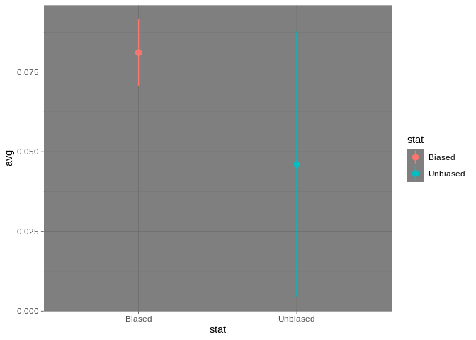

## CONCLUSION

Although Unbiased analysis increases the confidence interval significantly , as well as reduces the spread by almost half . The statistics still shows the polls to be significantly in favour of Joe Biden and none of the confidence interval include 0 . So we can confidently conclude the polls to be in favour of Joe Biden as of July 2020